# Análisis Exploratorio

Fabián Brenes Trejos

2/28/2021

El objetivo del trabajo consiste en estudiar la relación causal entre el **crecimiento económico** (representado por el PIB real) y el **desarrollo del sistema financiero** (se utiliza como variable proxy los créditos al sector privado en porcentajes del PIB nominal), mediante modelos multivariados temporales.

## PIB Real de Costa Rica

- Fuente primaria: Banco Central de Costa Rica
- Unidad de medida: Millones de colones encadenados

[interactive chart not shown]

## Créditos al sector privado

- Fuente primaria: Banco Central de Costa Rica
- Unidad de medida: Porcentaje del PIB nominal

[interactive chart not shown]

## Correlación

[interactive chart not shown]

Las variables en niveles muestran un alto nivel de correlación de 0.93.

Al correr una regresión lineal simple entre el PIB real en función del desarrollo del sistema financiero y gráficar los residuos estandarizados, se observan que en el periodo de la crisis financiera mundial (2008 y 2009), estos valores son mayor a 2 en valor absoluto. De igual manera, para diciembre 2019 el residuo estandarizado es mayor a 2.

## Variables de control

### Estadísticas Descriptivas

| Indicador | Nombre Completo | Unidad | Estadísticas Descriptivas Promedio | Estadísticas Descriptivas Mínimo | Estadísticas Descriptivas Máximo | Estadísticas Descriptivas Desviación Estándar | Estadísticas Descriptivas Coeficiente de Variación |
| --- | --- | --- | --- | --- | --- | --- | --- |
| distr | Distribución del Ingreso | % | 49.4 | 47.5 | 52.3 | 1.1 | 0.022 |
| ied | Inversión Extranjera Directa | Millones USD | 601.5 | 217.8 | 1187.3 | 218.7 | 0.364 |
| inflacion | Inflación | % | 2.8 | -1.1 | 6.2 | 2.1 | 0.750 |
| tbp | Tasa Básica Pasiva | % | 6.5 | 3.5 | 10.5 | 1.5 | 0.231 |

* Fuente: Banco Central de Costa Rica

### Gráficos de las Variables en Niveles

[interactive chart not shown]

### Gráficos de Dispersión vrs PIBr

[interactive chart not shown]

### Gráficos de Dispersión vrs Desarrollo del Sistema Financiero

[interactive chart not shown]

## Regresión Lineal

Ecuación: pibr ~ cred_pib+distr+ied+inflacion+tbp

```r
mod_lm <- lm(formula_mod_lineal, data = data)
summary(mod_lm)
```

```
##
## Call:
## lm(formula = formula_mod_lineal, data = data)
##
## Residuals:
##     Min      1Q  Median      3Q     Max
## -370958 -133257  -22078  115501  597871
##
## Coefficients:
##               Estimate Std. Error t value Pr(>|t|)
## (Intercept) -1667661.7  2502261.9  -0.666    0.509
## cred_pib    11076776.3  1243611.6   8.907  1.6e-10 ***
## distr          32772.0    39004.6   0.840    0.406
## ied              256.2      172.5   1.486    0.146
## inflacion      22118.9    27208.6   0.813    0.422
## tbp            53994.6    41875.9   1.289    0.206
## ---
## Signif. codes:  0 '***' 0.001 '**' 0.01 '*' 0.05 '.' 0.1 ' ' 1
##
## Residual standard error: 227800 on 35 degrees of freedom
## Multiple R-squared:  0.8782, Adjusted R-squared:  0.8608
## F-statistic: 50.45 on 5 and 35 DF,  p-value: 5.095e-15
```

### Evaluación de los supuestos del modelo

#### 1. Multicolinealidad

Las covariables no presentan una alta multicolinealidad.

```r
vif(mod_lm)
```

```
##  cred_pib     distr       ied inflacion       tbp
##  4.412035  1.438088  1.095940  2.466815  3.071036
```

#### 2. Homocedasticidad

```r
bptest(mod_lm)
```

```
##
##  studentized Breusch-Pagan test
##
## data:  mod_lm
## BP = 5.7993, df = 5, p-value = 0.3262
```

#### 3. Autocorrelación en los residuos

El modelo presenta autocorrelación en el residuo.

```r
bgtest(mod_lm)
```

```
##
##  Breusch-Godfrey test for serial correlation of order up to 1
##
## data:  mod_lm
## LM test = 12.875, df = 1, p-value = 0.000333
```

#### 4. Normalidad de los residuos

Los residuos del modelo siguen una distribución normal.

```r
shapiro.test(mod_lm$residuals)
```

```
##
##  Shapiro-Wilk normality test
##
## data:  mod_lm$residuals
## W = 0.954, p-value = 0.09679
```

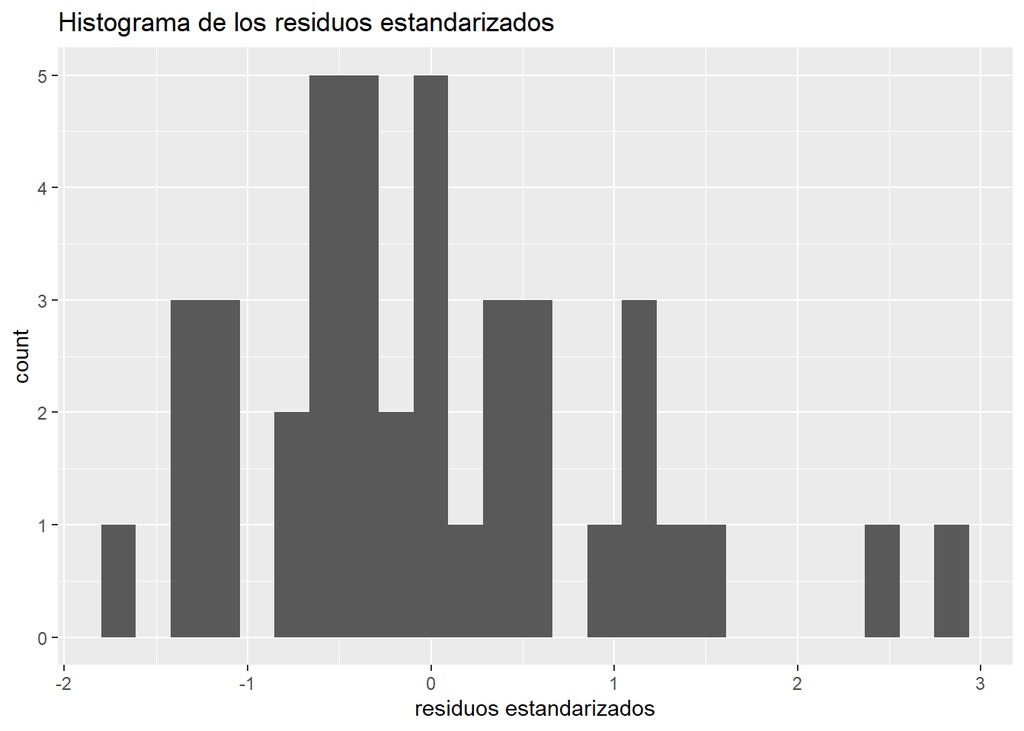

```r
tibble(`residuos estandarizados` = scale(mod_lm$residuals)) %>%
  ggplot(aes(x = `residuos estandarizados`)) + geom_histogram(bins = 25) +
  ggtitle("Histograma de los residuos estandarizados")
```